# Publication figure report

Author

Affiliation

none

manual

**Important**

A manual command generated this report without an LLM model. No separate human scientific review is part of this fixed recipe. The report records the selected recipe and does not claim a new statistical method.

## Figure

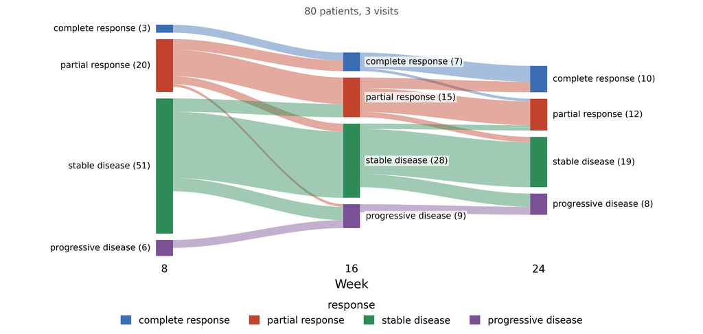

Publication figure

## Statistical results

| from_visit | to_visit | from_state | to_state | n | omnibus_test | omnibus_statistic | omnibus_df1 | omnibus_df2 | omnibus_p |
| --- | --- | --- | --- | --- | --- | --- | --- | --- | --- |
| 8 | 16 | complete response | complete response | 3 |  |  |  |  |  |
| 8 | 16 | partial response | complete response | 4 |  |  |  |  |  |
| 8 | 16 | partial response | partial response | 10 |  |  |  |  |  |
| 8 | 16 | partial response | stable disease | 3 |  |  |  |  |  |
| 8 | 16 | partial response | progressive disease | 1 |  |  |  |  |  |
| 8 | 16 | stable disease | partial response | 5 |  |  |  |  |  |
| 8 | 16 | stable disease | stable disease | 25 |  |  |  |  |  |
| 8 | 16 | stable disease | progressive disease | 5 |  |  |  |  |  |
| 8 | 16 | progressive disease | progressive disease | 3 |  |  |  |  |  |
| 16 | 24 | complete response | complete response | 6 |  |  |  |  |  |
| 16 | 24 | complete response | partial response | 1 |  |  |  |  |  |
| 16 | 24 | partial response | complete response | 4 |  |  |  |  |  |
| 16 | 24 | partial response | partial response | 9 |  |  |  |  |  |
| 16 | 24 | partial response | stable disease | 2 |  |  |  |  |  |
| 16 | 24 | stable disease | partial response | 2 |  |  |  |  |  |
| 16 | 24 | stable disease | stable disease | 17 |  |  |  |  |  |
| 16 | 24 | stable disease | progressive disease | 5 |  |  |  |  |  |
| 16 | 24 | progressive disease | progressive disease | 3 |  |  |  |  |  |

## Methods

The state response of 80 patients (patient) was followed across 3 visits of week (8, 16, 24). Visits are in numeric order, and states in the order set by the analyst (complete response, partial response, stable disease, progressive disease). The diagram shows 108 transitions between consecutive visits; a patient missing at a visit takes no part in the transitions into or out of it, and the transitions table gives every count. The diagram is descriptive, and no test was applied because more than two visits. Drawn in Python 3.10.12 with matplotlib 3.10.9; the test uses statsmodels 0.15.0.

## Plot configuration

The complete plot configuration is in `plot_config.yaml`.

## Provenance

| field | value |
| --- | --- |
| repository | pubready |
| repository_version | 4.0.0 |
| git_commit | 567ce8900bdb5db88369d131c8d787b042b3af57 |
| git_dirty | FALSE |
| llm_provider | none |
| llm_model | none |
| agent_harness | manual |
| agent_harness_version | not_recorded |
| container_image | localhost/pubready:4.0.0 |
| container_digest | sha256:0f57027a3fbca5ec9d41d74ca91226fbdf45d94b1a85f271637d12733db5d483 |
| input | {“file”: “input_response.csv”, “md5”: “c904039b35f8f4e54992ca687d27384a”, “sha256”: “d6b6ba5c1c315133158bff3441fd72223f9c75710a9724354efae2d2be283e5d”} |
| command | figkit plot –recipe sankey |
| analysis_options | {“engine”: “python”, “recipe”: “sankey”, “data”: {“file”: “sankey.csv”, “x”: “week”, “y”: “response”, “fill”: null, “facet”: null, “time”: null, “event”: null, “annotation”: null, “covariates”: null, … |
| random_seeds | not_applicable |
| session_record | session_info.txt |
| created_utc | 2026-07-18T00:00:00Z |
| review_state | not_applicable |
| reviewer | none |
| quarto_version | 1.11.4 |

The report source reads only files in this bundle.